# Parasite aggregation and burden

### We don’t only care about prevalence

- Prevalence : fraction of the population infected (infection is binary here)
- Intensity : the number of parasites within an infected host (*how* infected is the host?)

### Why do we care about intensity?

- outcomes (death is more likely if you have more parasites)
- transmission potential (transmission is more likely when you have more parasites)
- mitigation targets (who do we treat?)

### Outcomes (Ebola)

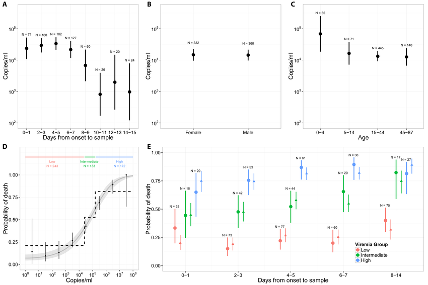

<sub>Faye et al. 2015 *PLoS Medicine*</sub>

### Transmission potential

- supershedders: high infection burden can lead to shedding lots of pathogen in the environment (increases transmission rate)
- supershedding is different than superspreading
- Transmission potential increases for both external parasites and internal parasites
- Even for sexually-transmitted infections (so transmission goes up, even though contact does not change; \(\beta = c*a\)

### An example of HIV

Higher viremia means higher transmission potential

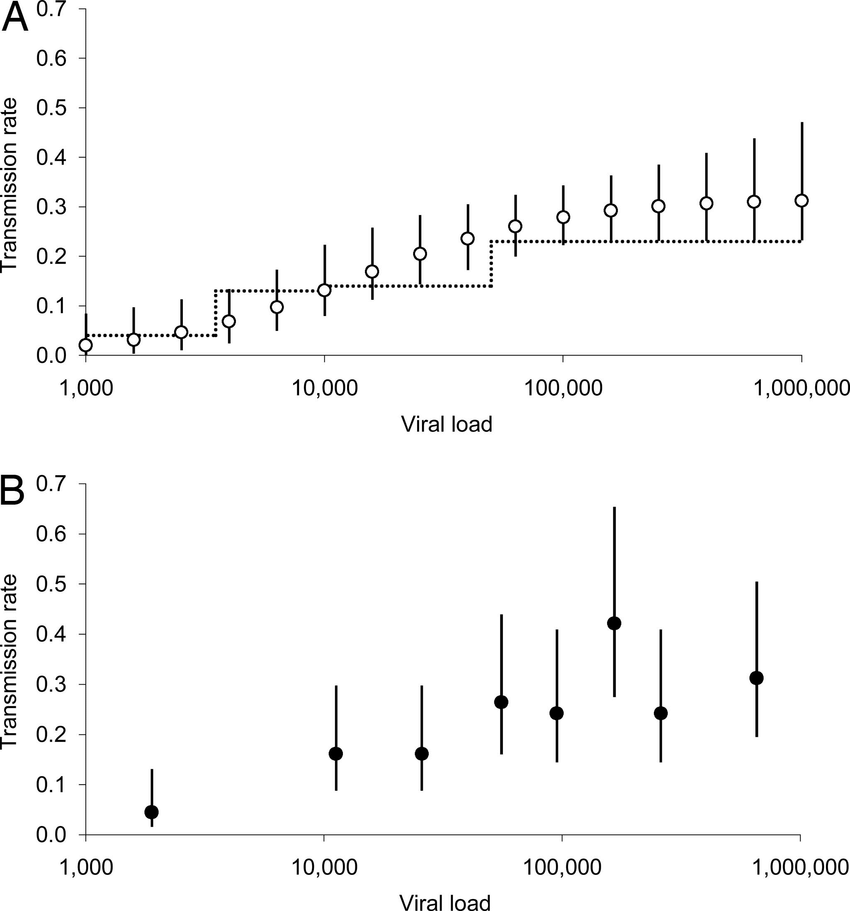

<sub>Fraser et al. 2007 PNAS</sub>

### But once symptoms start, contact goes down

There is nuance here, as transmission depends on contact and infectivity

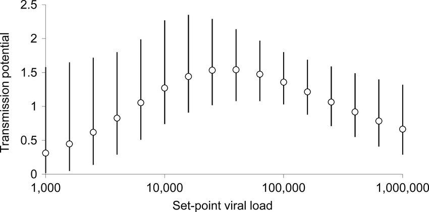

<sub>Fraser et al. 2007 PNAS</sub>

### Timeline of infection

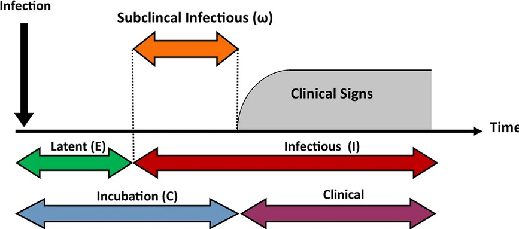

<sub>Arzt et al. 2019 Scientific Reports</sub>

### Monogean ectoparasites of guppies

Saturating transmission potential (there’s only so many parasites you can have before transmission potential saturates)

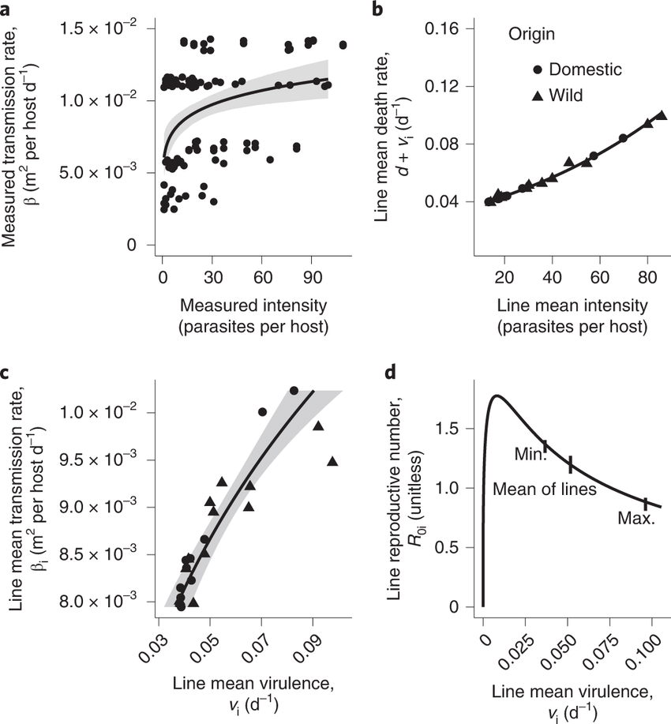

<sub>Walsman et al. 2022 Nature E&E</sub>

### Mitigation

> If we can identify phenotypes of heavily infected individuals, we can target treatment

### Target high-risk individuals

- could estimate social contact network (variation in contact rate \(c\))
- or could use measures associated with burden (and subsequently probability of infection)
  - so vaccinate based on which individuals you think are either highest risk or would have the highest burden if infected

### Targeted vaccinations of highly central individuals

- Knowing social network structure helps vaccination
- Even using traits to target vaccination still works better than random

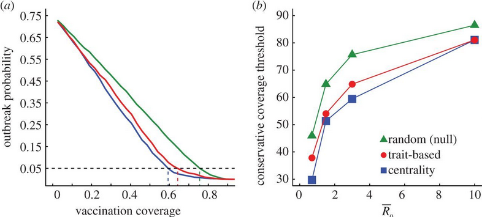

<sub>Rushmore et al. 2014 Interface</sub>

### What causes variation in infection intensity within a host population?

- host sex
- time of exposure
- superinfection
- home range size
- immune function

### Sex-biased parasitism

### Evidence in rodents and bats

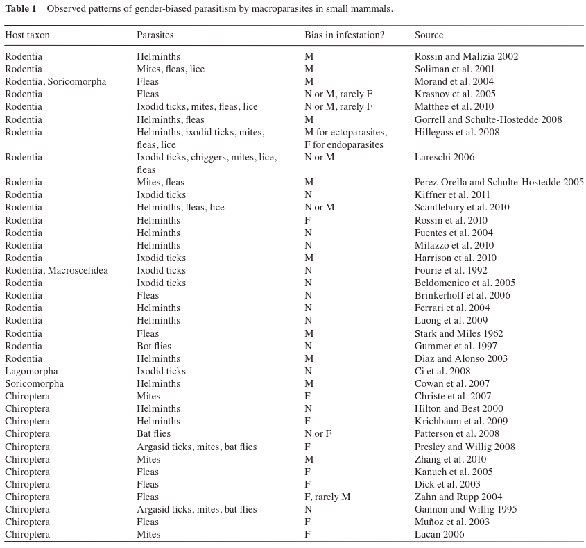

<sub>Krasnov et al. 2012 *Mammalia*</sub>

### Sex-biased parasitism

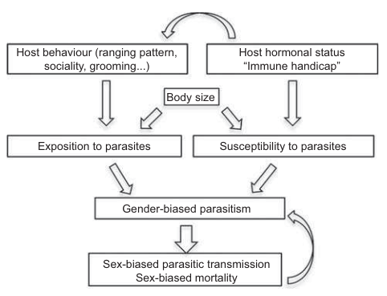

<sub>Krasnov et al. 2012 *Mammalia*</sub>

### Other examples of sex-biased parasitism

### Time of exposure

- If all host individuals were equal, there could still be aggregated parasite burdens

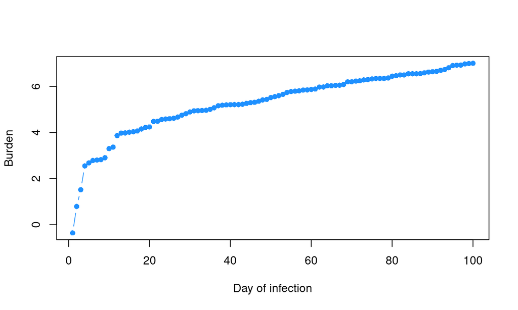

### Timeline of infection

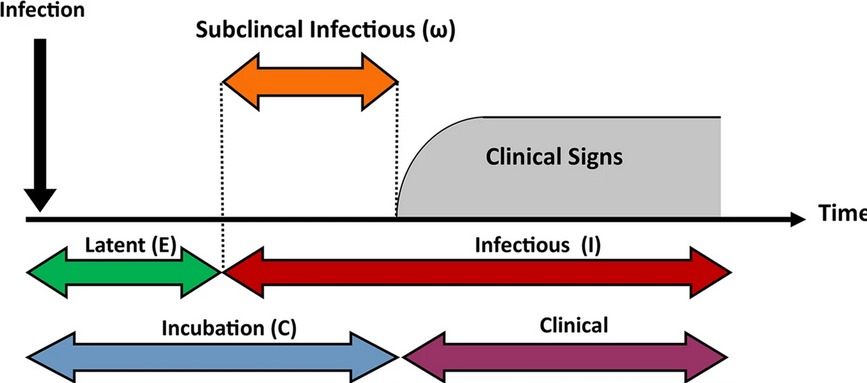

<sub>Arzt et al. 2019 Scientific Reports</sub>

### Simulated data to show how this matters

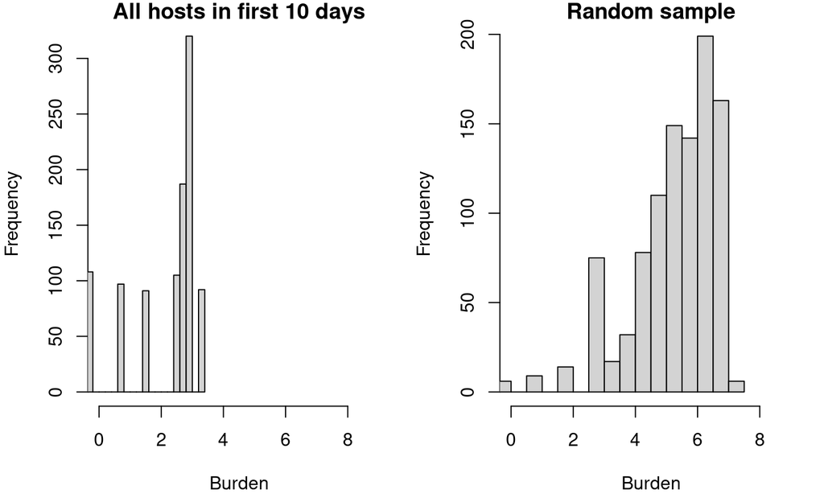

### Does not really happen though

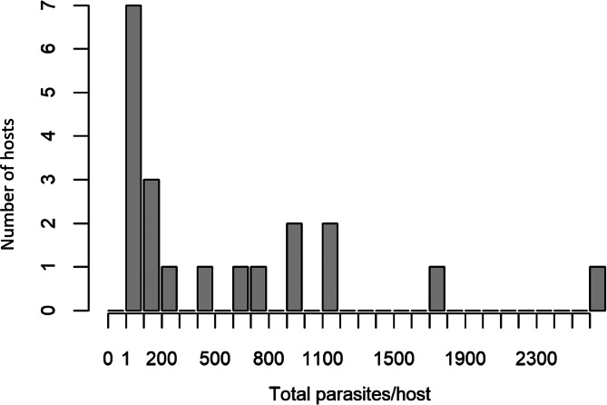

<sub>Tinsley et al. 2020 *Parasitology*</sub>

### Superinfection

Superinfection is when an infected individual is exposed again to a parasite, and it infects.

- This serves to increase pathogen burden in infected hosts, as it disrupts the infection timeline by adding more parasites to an individual.
- This effect is pronounced when hosts vary in their exposure probability, such that some individuals just have a higher risk of exposure and resulting superinfection.

### Home range size

### Immune function

## End of lecture 1

### What have we learned so far?

- There is variation in parasite burden within a population
- This variation is related to host traits

### Parasite aggregation

- This variation in infection intensity (aka parasite burden) gets at the fundamental idea that parasites are aggregated within host populations

### What does infection intensity mean for microparasites and macroparasites?

- Viremia (viral load)
  - Infectious copies per ml (blood) or g (host tissue)
- Ectoparasite burdens
  - Count of individual parasites (sometimes standardized by host weight)

### How do we measure parasite aggregation?

- Variance-mean ratio
- Negative binomial fit (\(k\))
- Mean crowding
- Patchiness
- Poulin’s \(D\)
- Hoover’s index

https://www.otago.ac.nz/parasitegroup/PDF%20papers/Morrilletal2023-IJP.pdf

### Variance-mean ratio

Variance divided by the mean

\[ VMR = \dfrac{\sigma^2}{\mu} \]

### Negative binomial distribution

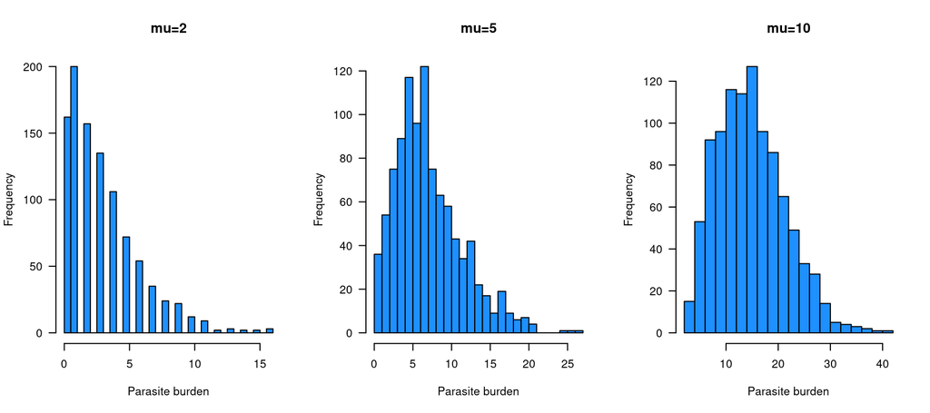

\[ k = \dfrac{(\mu^2 - \sigma^2)/N}{(\sigma^2 - \mu^2)} \]

### Mean crowding

\[ m* = \dfrac{\sum x^2_j}{\sum x_j} - 1 \]

### Patchiness

\[ P = \dfrac{m*}{\mu} \]

### Poulin’s D

\[ D = 1 - \dfrac{2\sum^N_i=1 \sum^i_j=1 x_j}{\mu N(N+1)} \]

### Hoover’s index

\[ H = \dfrac{\sum^N_i=1 |x_i - \mu | }{2\sum^N_i=1 x_i} \]

### Collinearity among aggregation indices

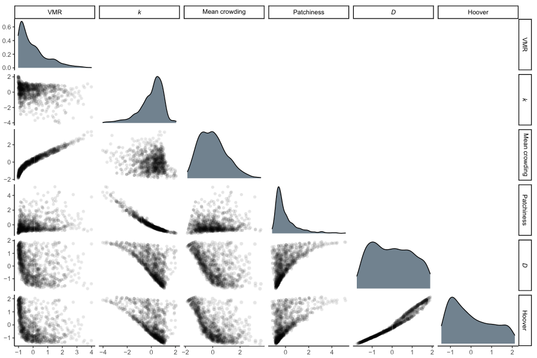

### What causes variation in infection intensity between host species for the same parasite?

- other stuff.
- trait distributions of hosts
- phylogenetic bits
- parasite specificity

### other stuff

### trait distributions of hosts

### phylogenetic bits

### parasite specificity

### Are aggregated burdens comparable across host species?

Not really

### Are aggregated burdens comparable across parasite species?

Not really

### Are aggregated burdens a property of the host or the parasite?